# machine learning

Seke Pascal

November 6, 2016

## Background

Using devices such as Jawbone Up, Nike FuelBand, and Fitbit it is now possible to collect a large amount of data about personal activity relatively inexpensively. These type of devices are part of the quantified self movement - a group of enthusiasts who take measurements about themselves regularly to improve their health, to find patterns in their behavior, or because they are tech geeks. One thing that people regularly do is quantify how much of a particular activity they do, but they rarely quantify how well they do it. In this project, your goal will be to use data from accelerometers on the belt, forearm, arm, and dumbell of 6 participants. They were asked to perform barbell lifts correctly and incorrectly in 5 different ways. More information is available from the website here: http://groupware.les.inf.puc-rio.br/har (see the section on the Weight Lifting Exercise Dataset).

### Load packages

In this assignment we will explore the data using the package `caret`, `rpart`, and `randomForest` for our prediction. load the different package:

```r
library(knitr)
library(caret)
library(rpart)
library(randomForest)
set.seed(3223)
```

### Data loading

data was downloaded directly to my home directory via the url and will be read directly from the preceding directory.

```r
training <- read.csv("pml-training.csv",row.names=1,na.strings = "")
testing <- read.csv("pml-testing.csv",row.names=1,na.strings = "NA")
```

let’s create a partition for our usable dataset.

```r
inTrain  <- createDataPartition(training$classe, p=0.7, list=FALSE)
TrainSet <- training[inTrain, ]
TestSet  <- training[-inTrain, ]
dim(TrainSet)
```

```
## [1] 13737   159
```

```r
dim(TestSet)
```

```
## [1] 5885  159
```

let’s remove variables with Nearly Zero Variance and all the NA’s on th data.

```r
N_Z_V <- nearZeroVar(TrainSet)
TrainSet <- TrainSet[, -N_Z_V]
TestSet  <- TestSet[, -N_Z_V]
dim(TrainSet)
```

```
## [1] 13737    75
```

Removing the NA’s

```r
AllNA    <- sapply(TrainSet, function(x) mean(is.na(x))) > 0.95
TrainSet <- TrainSet[, AllNA==FALSE]
TestSet  <- TestSet[, AllNA==FALSE]
dim(TestSet)
```

```
## [1] 5885   58
```

Removing unuseful variable from column(1:5)

```r
TrainSet <- TrainSet[, -(1:5)]
TestSet  <- TestSet[, -(1:5)]
dim(TrainSet)
```

```
## [1] 13737    53
```

## Prediction method: Random Forest

one method will be applied to model the regressions (in the Train dataset) and the best one (with higher accuracy when applied to the Test dataset) will be used for the quiz predictions. The method is: Random Forests.

```r
set.seed(3223)
RF_control <- trainControl(method="cv", number=3, verboseIter=FALSE)
```

```r
Fit_RandForest <- train(classe ~ ., data=TrainSet, method="rf",
                          trControl=RF_control)
Fit_RandForest$finalModel
```

```
##
## Call:
##  randomForest(x = x, y = y, mtry = param$mtry)
##                Type of random forest: classification
##                      Number of trees: 500
## No. of variables tried at each split: 27
##
##         OOB estimate of  error rate: 0.63%
## Confusion matrix:
##      A    B    C    D    E class.error
## A 3902    3    1    0    0 0.001024066
## B   20 2632    5    1    0 0.009781791
## C    0   11 2375   10    0 0.008764608
## D    0    1   23 2227    1 0.011101243
## E    0    2    3    5 2515 0.003960396
```

let’s do some prediction now on the test data.

```r
predict_RandForest <- predict(Fit_RandForest, newdata=TestSet)
confMat_RandForest <- confusionMatrix(predict_RandForest, TestSet$classe)
confMat_RandForest
```

```
## Confusion Matrix and Statistics
##
##           Reference
## Prediction    A    B    C    D    E
##          A 1671    9    0    0    0
##          B    1 1125    7    0    0
##          C    1    5 1016    3    1
##          D    0    0    3  960    3
##          E    1    0    0    1 1078
##
## Overall Statistics
##
##                Accuracy : 0.9941
##                  95% CI : (0.9917, 0.9959)
##     No Information Rate : 0.2845
##     P-Value [Acc > NIR] : < 2.2e-16
##
##                   Kappa : 0.9925
##  Mcnemar's Test P-Value : NA
##
## Statistics by Class:
##
##                      Class: A Class: B Class: C Class: D Class: E
## Sensitivity            0.9982   0.9877   0.9903   0.9959   0.9963
## Specificity            0.9979   0.9983   0.9979   0.9988   0.9996
## Pos Pred Value         0.9946   0.9929   0.9903   0.9938   0.9981
## Neg Pred Value         0.9993   0.9971   0.9979   0.9992   0.9992
## Prevalence             0.2845   0.1935   0.1743   0.1638   0.1839
## Detection Rate         0.2839   0.1912   0.1726   0.1631   0.1832
## Detection Prevalence   0.2855   0.1925   0.1743   0.1641   0.1835
## Balanced Accuracy      0.9980   0.9930   0.9941   0.9973   0.9979
```

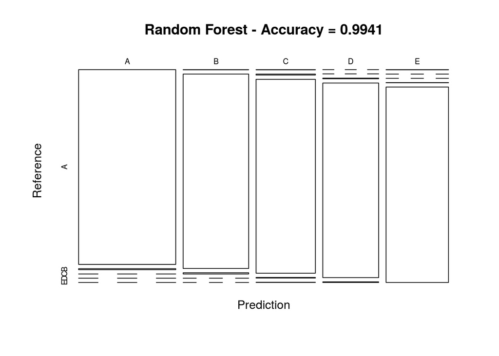

```r
plot(confMat_RandForest$table, col = confMat_RandForest$byClass,
     main = paste("Random Forest - Accuracy =",
                  round(confMat_RandForest$overall['Accuracy'], 4)))
```

let’s use the Random Forest model to predict our data.

## Prediction for the 20 question quiz.

```r
data_predict <- predict(Fit_RandForest, newdata=testing)
data_predict
```

```
##  [1] B A B A A E D B A A B C B A E E A B B B
## Levels: A B C D E
```